# Business Report: Store Demand Forecasting

Pandu Purwadi

July 30, 2020

# Background

In this case I will create a time series model using a sales dataset provided in Kaggle. This dataset consist of 4 years of store-item sales data. It perform a time series analysis and forecasting using Prophet model.

```r
library(dplyr)
library(lubridate)
library(ggplot2)
library(prophet)
```

# Data Preparation

```r
sales <- read.csv("data_input/dive-deeper/train.csv")

glimpse(sales)
```

```
## Rows: 730,500
## Columns: 4
## $ date  <chr> "2013-01-01", "2013-01-02", "2013-01-03", "2013-01-04", "2013...
## $ store <int> 1, 1, 1, 1, 1, 1, 1, 1, 1, 1, 1, 1, 1, 1, 1, 1, 1, 1, 1, 1, 1...
## $ item  <int> 1, 1, 1, 1, 1, 1, 1, 1, 1, 1, 1, 1, 1, 1, 1, 1, 1, 1, 1, 1, 1...
## $ sales <int> 13, 11, 14, 13, 10, 12, 10, 9, 12, 9, 9, 7, 10, 12, 5, 7, 16,...
```

```r
head(sales)
```

```
##         date store item sales
## 1 2013-01-01     1    1    13
## 2 2013-01-02     1    1    11
## 3 2013-01-03     1    1    14
## 4 2013-01-04     1    1    13
## 5 2013-01-05     1    1    10
## 6 2013-01-06     1    1    12
```

```r
tail(sales)
```

```
##              date store item sales
## 730495 2016-12-26    10   50    61
## 730496 2016-12-27    10   50    60
## 730497 2016-12-28    10   50    43
## 730498 2016-12-29    10   50    68
## 730499 2016-12-30    10   50    63
## 730500 2016-12-31    10   50    64
```

This is sales report from 10 stores in 1st January 2013 - 31st December 2016 periods. There are 4 columns observations and variables, consist of information such as date, store number, item number, and item’s sales. Data contains 730,500 rows. It has two varieties of type, date has character type, meanwhile store, item, and sales has integer data type.

After import and understanding data, arrange it sale based on date.

```r
sales_2 <- sales %>%
  mutate(date = ymd(date)) %>%
  arrange(date)
```

Then doing data aggregation in dataset from store and item sales. In data above shown column date and total demand based on each transactions.

```r
daily_demand <- sales_2 %>%
  group_by(date) %>%
  summarise(
    demand = sum(sales)
  )
head(daily_demand)
```

```
## # A tibble: 6 x 2
##   date       demand
##   <date>      <int>
## 1 2013-01-01  13696
## 2 2013-01-02  13678
## 3 2013-01-03  14488
## 4 2013-01-04  15677
## 5 2013-01-05  16237
## 6 2013-01-06  17291
```

# Visual Exploratory Analysis

Data preparation was completed. Then, we make visualization to understand easily the insight of data than tabular data. X axis explains date and y axis is demand for items.

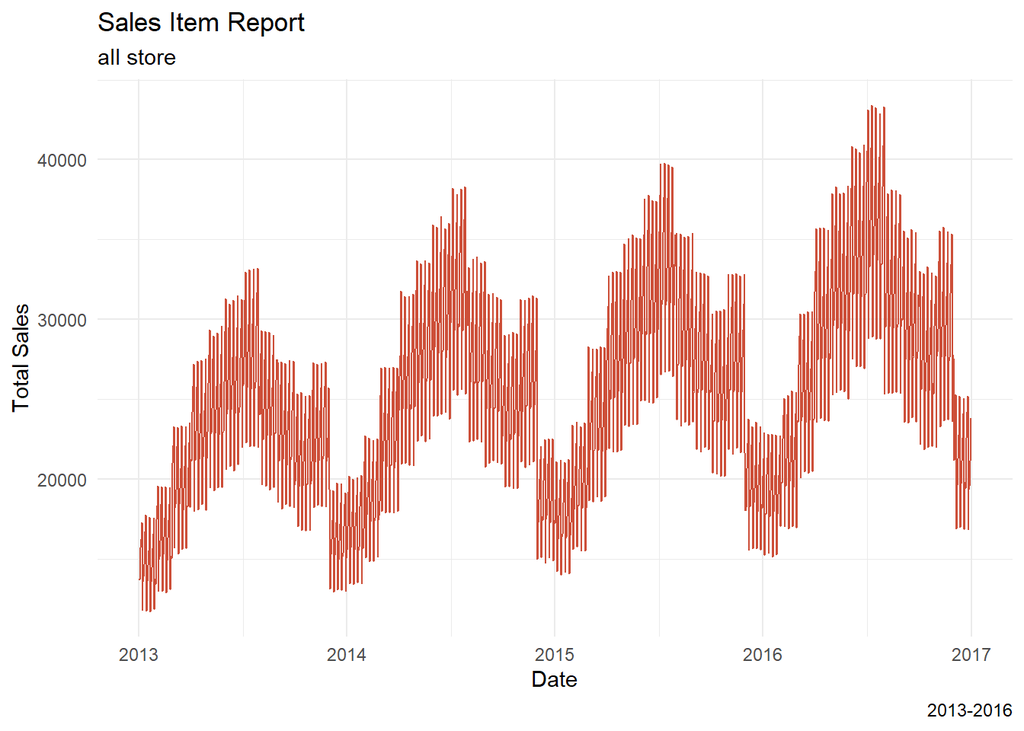

```r
daily_demand %>%
  ggplot(aes(x=date, y=demand)) +
  geom_line(color = "tomato3", group=1) +
  labs(
    title = "Sales Item Report",
    subtitle = "all store",
    caption = "2013-2016",
    x = "Date",
    y = "Total Sales"
  ) +
  theme_minimal()
```

Data visualization has been created. First, Based on its visualization, we understand and know insight easily. Total sales increase from 2013 until 2016. Second, we have pattern in our total sales, same each year with best sales in middle of year.

# Baseline Prophet Model

We are not yet satisfied with visualization in current condition. What we need is prediction for next performance total sales, because it is our goals. So, what we need next is make simple prophet model. Prohet has it rules to fit our data set in its package. Rename date and demand into ds and y.

```r
train_sales <- daily_demand %>%
  rename(
    ds = "date",
    y = "demand"
  )
glimpse(train_sales)
```

```
## Rows: 1,461
## Columns: 2
## $ ds <date> 2013-01-01, 2013-01-02, 2013-01-03, 2013-01-04, 2013-01-05, 201...
## $ y  <int> 13696, 13678, 14488, 15677, 16237, 17291, 11769, 13560, 13878, 1...
```

Then, make our dataset fit with prophet, adjust how many prediction we need. Let’s try for 1 year, because our dataset has frequency in day, so convert 1 year to 365 days. After that, make plot to visualize prediction.

```r
model_sales <- prophet() %>%
  fit.prophet(train_sales)
range(train_sales$ds)
```

```
## [1] "2013-01-01" "2016-12-31"
```

```r
future_365 <- make_future_dataframe(model_sales, periods = 365, freq = "day")
glimpse(future_365)
```

```
## Rows: 1,826
## Columns: 1
## $ ds <dttm> 2013-01-01, 2013-01-02, 2013-01-03, 2013-01-04, 2013-01-05, 201...
```

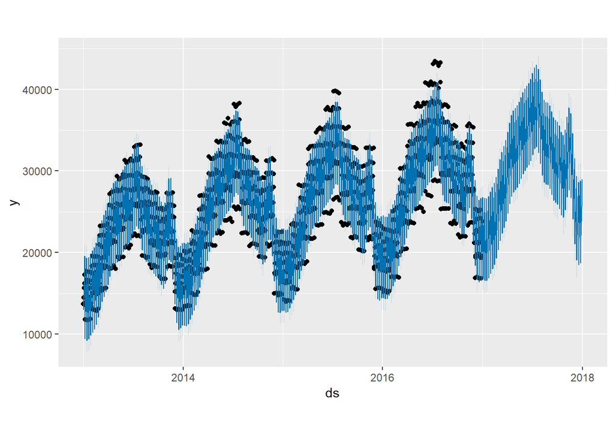

```r
forecast_365 <- predict(model_sales, future_365)
plot(model_sales, forecast_365)
```

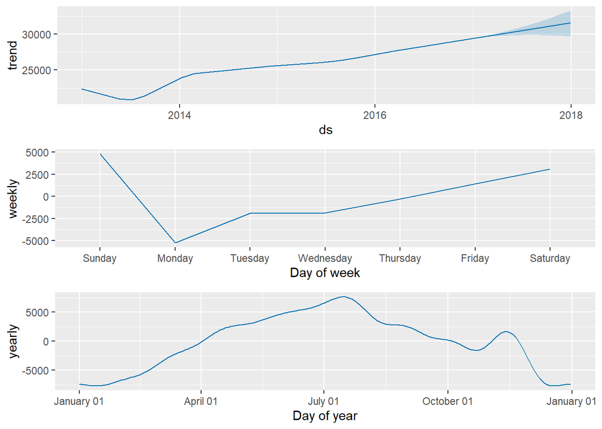

```r
prophet_plot_components(model_sales, forecast_365)
```

# Model Fine Tuning

This step to customize model as we want. Add more conditions, like holiday, changepoint, and seasonality. First model above is default from Prophet, some case not fit with real condition, so we need to remodel it with model tuning. Let see how sales data performance through trend line Y = mx + c.

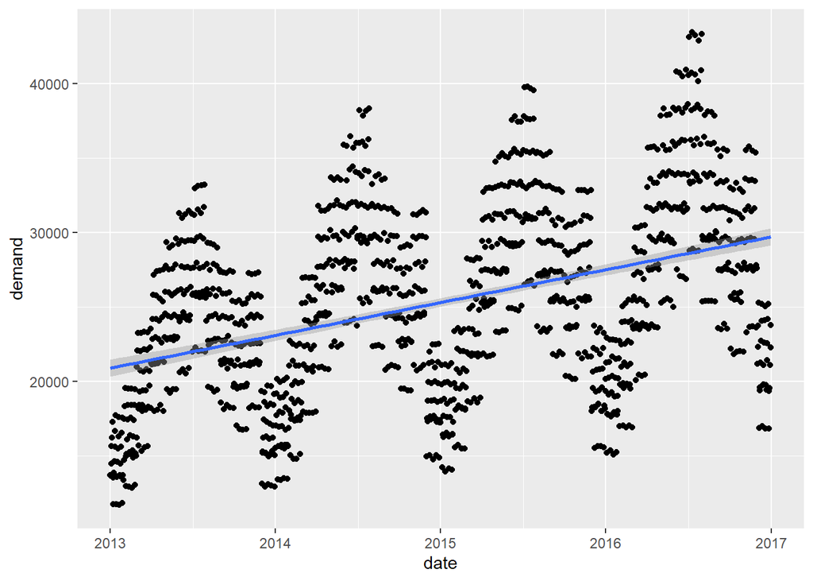

```r
daily_demand %>%
  ggplot(aes(x=date, y=demand)) +
  geom_point() +
  geom_smooth(method = "lm")
```

Trend sales has uptrend or increase each year.

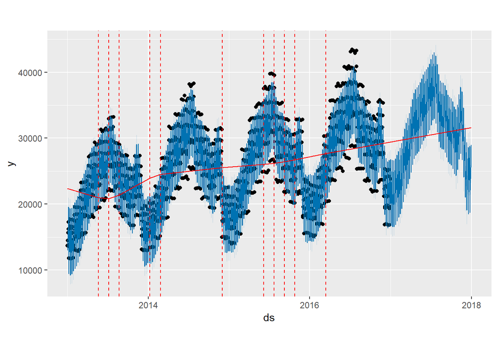

```r
plot(model_sales, forecast_365) +
  add_changepoints_to_plot(model_sales)
```

Graph above show tell us about changepoint happen in our data. Some points makes significant different values than regular condition.

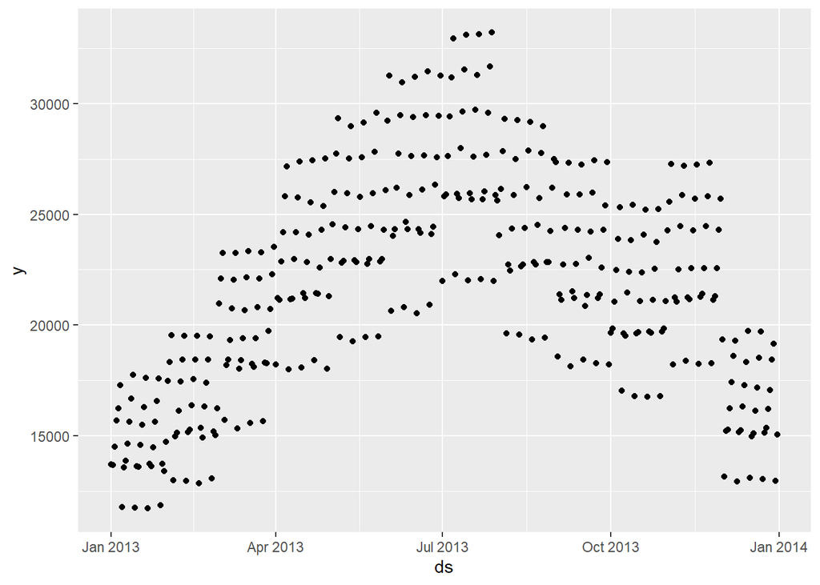

```r
before_2014 <- daily_demand %>%
  mutate(
    year=year(date)
  ) %>%
  filter(year < 2014) %>%
  rename(
    ds = "date",
    y = "demand"
  )

after_2014 <- daily_demand %>%
  mutate(
    year = year(date)
  ) %>%
  filter(year >= 2014) %>%
  rename(
    ds = "date",
    y = "demand"
  )

ggplot(before_2014, aes(x=ds, y=y)) +
  geom_point()
```

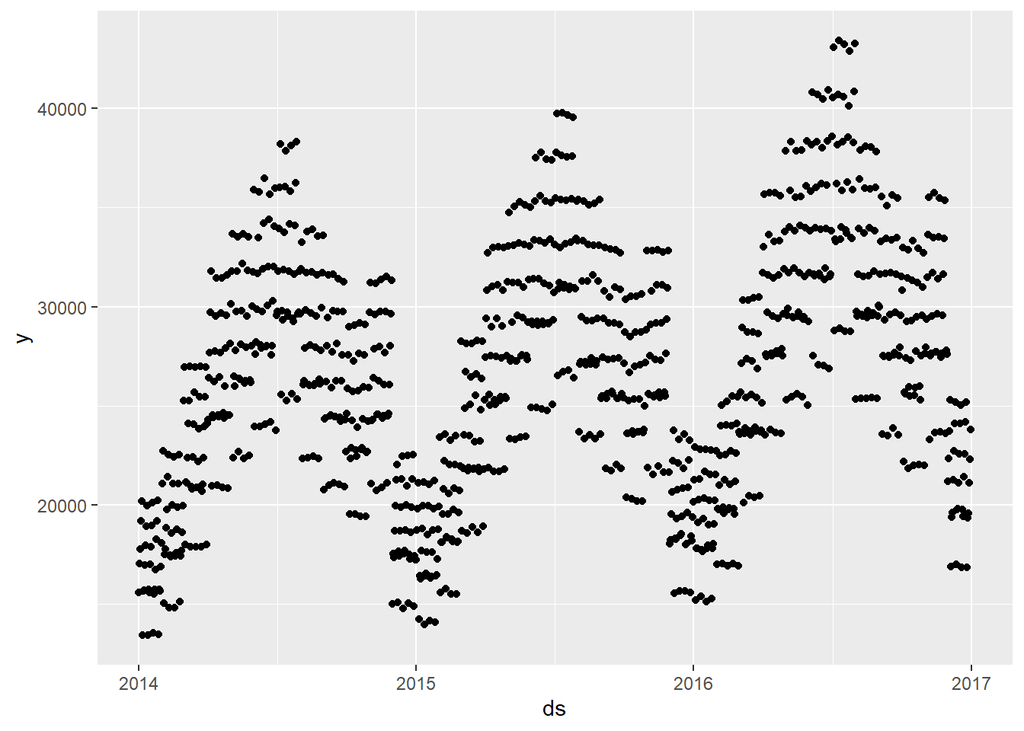

```r
ggplot(after_2014, aes(x=ds, y=y)) +
  geom_point()
```

Seperated data into two dataframe. First is before 2014 and second one is after 2014. Before 2014, especially sales 2013 shows different pattern than the another years.

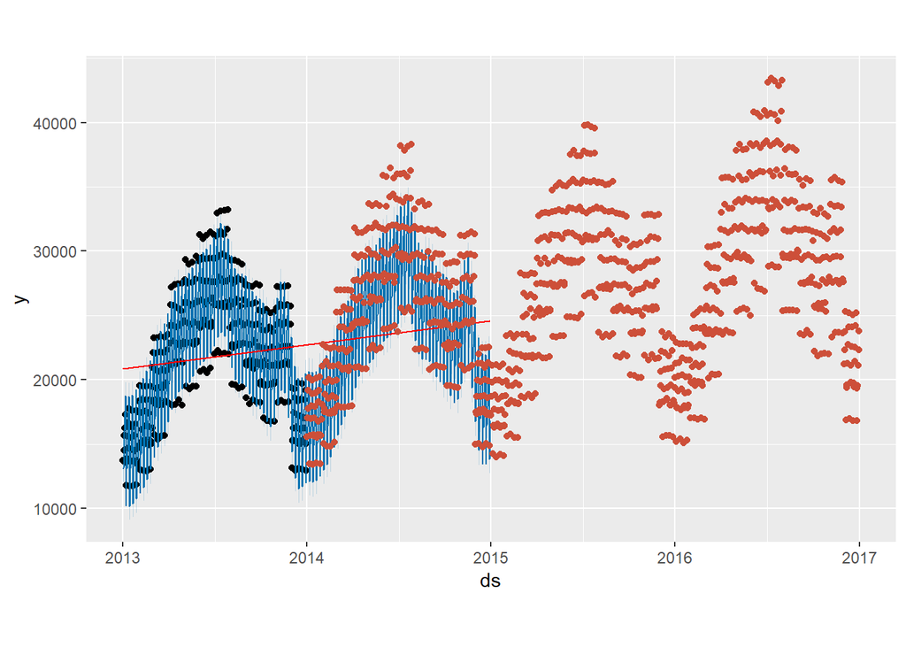

```r
model_before_2014 <- prophet(yearly.seasonality = TRUE,
                             changepoints = ymd(c("2013-01-01")),
                             changepoint.prior.scale = 0.5) %>%
  fit.prophet(before_2014)
future_before_2014 <- make_future_dataframe(model_before_2014, periods = 365)
forecast_before_2014 <- predict(model_before_2014, future_before_2014)
plot(model_before_2014, forecast_before_2014) +
  add_changepoints_to_plot(model_before_2014) +
  geom_point(data = after_2014, aes(x=as.POSIXct(ds), y=y), color="tomato3")
```

Try to model with data before and after 2014. We can see it above the graph shows us the visualization insight.

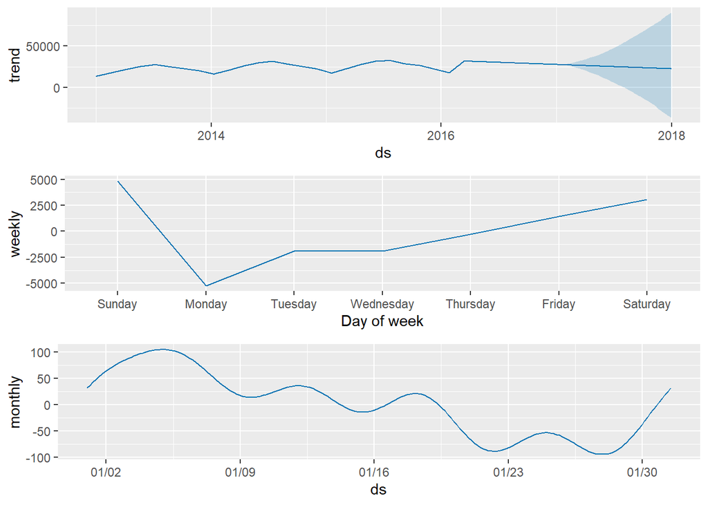

```r
model_6_monthly <- prophet(changepoint.prior.scale = 0.5, yearly.seasonality = FALSE ) %>%
  add_seasonality(name = "monthly", period = 30.5, fourier.order = 5) %>%
  fit.prophet(train_sales)
future_6_monthly <- make_future_dataframe(model_6_monthly, periods = 365)
forecast_6_monthly <- predict(model_6_monthly, future_6_monthly)
prophet_plot_components(model_6_monthly, forecast_6_monthly)
```

Turn off for yearly seasonality and try monthly seasonality. In start of month sales seems higher than other date in one month.

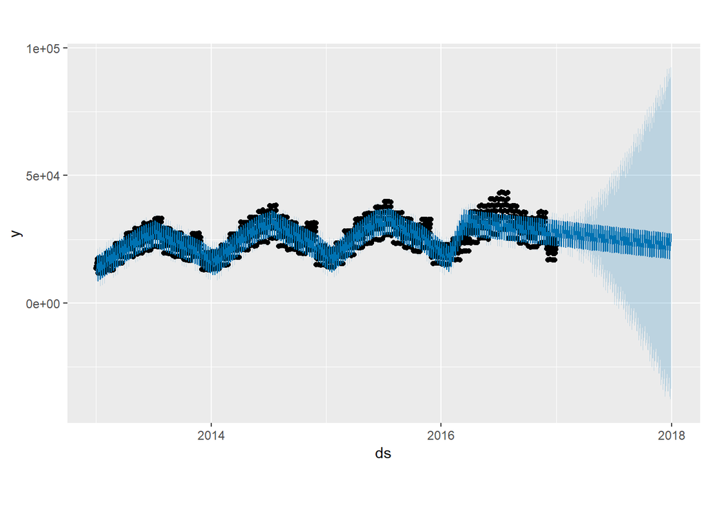

```r
plot(model_6_monthly, forecast_6_monthly)
```

This is visualization of month seasonality of this data.

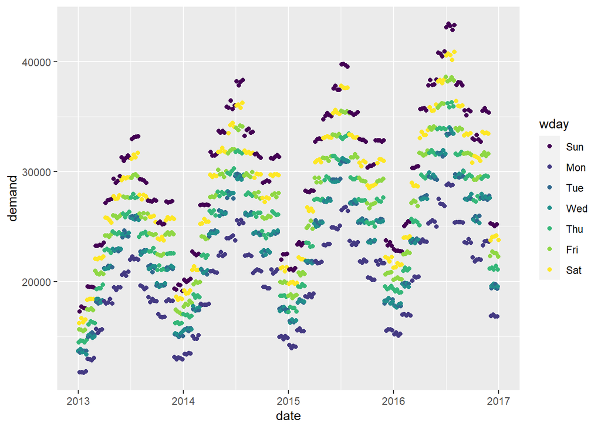

```r
daily_demand %>%
  mutate(
    wday = wday(date, label = TRUE)
  ) %>%
  ggplot(aes(x=date, y=demand)) +
  geom_point(aes(color=wday))
```

This is sorter sales data based on day in one week. Sunday has higher value than other days, so Saturday too. It can be in weekend sales has good performance.

```r
daily_demand %>%
  filter(
    demand > 40000)
```

```
## # A tibble: 14 x 2
##    date       demand
##    <date>      <int>
##  1 2016-06-05  40814
##  2 2016-06-12  40709
##  3 2016-06-19  40460
##  4 2016-06-26  40921
##  5 2016-07-02  40534
##  6 2016-07-03  43103
##  7 2016-07-09  40713
##  8 2016-07-10  43427
##  9 2016-07-16  40583
## 10 2016-07-17  43247
## 11 2016-07-23  40143
## 12 2016-07-24  42881
## 13 2016-07-30  40857
## 14 2016-07-31  43294
```

Filter high demand more than 40000 in 2016. Those values not touch by blue line in prediction, so we can add it to holiday effect.

```r
holiday_0 <-
  data.frame(
    holiday="middle_year",
    ds=dmy(c("26-06-2013", "31-07-2013","26-06-2014",
             "31-07-2014","26-06-2015", "31-07-2015","26-06-2016",
             "31-07-2016")),
    lower_window = -5,
    upper_window = 0
  )
holiday_0
```

```
##       holiday         ds lower_window upper_window
## 1 middle_year 2013-06-26           -5            0
## 2 middle_year 2013-07-31           -5            0
## 3 middle_year 2014-06-26           -5            0
## 4 middle_year 2014-07-31           -5            0
## 5 middle_year 2015-06-26           -5            0
## 6 middle_year 2015-07-31           -5            0
## 7 middle_year 2016-06-26           -5            0
## 8 middle_year 2016-07-31           -5            0
```

```r
holiday_2 <-
  data.frame(
    holiday="newyeareve",
    ds=dmy(c("31-12-2013", "31-12-2014", "31-12-2015", "31-12-2016")),
    lower_window = -5,
    upper_window = 0
  )
holiday_2
```

```
##      holiday         ds lower_window upper_window
## 1 newyeareve 2013-12-31           -5            0
## 2 newyeareve 2014-12-31           -5            0
## 3 newyeareve 2015-12-31           -5            0
## 4 newyeareve 2016-12-31           -5            0
```

```r
holiday <- bind_rows(holiday_0, holiday_2)
holiday
```

```
##        holiday         ds lower_window upper_window
## 1  middle_year 2013-06-26           -5            0
## 2  middle_year 2013-07-31           -5            0
## 3  middle_year 2014-06-26           -5            0
## 4  middle_year 2014-07-31           -5            0
## 5  middle_year 2015-06-26           -5            0
## 6  middle_year 2015-07-31           -5            0
## 7  middle_year 2016-06-26           -5            0
## 8  middle_year 2016-07-31           -5            0
## 9   newyeareve 2013-12-31           -5            0
## 10  newyeareve 2014-12-31           -5            0
## 11  newyeareve 2015-12-31           -5            0
## 12  newyeareve 2016-12-31           -5            0
```

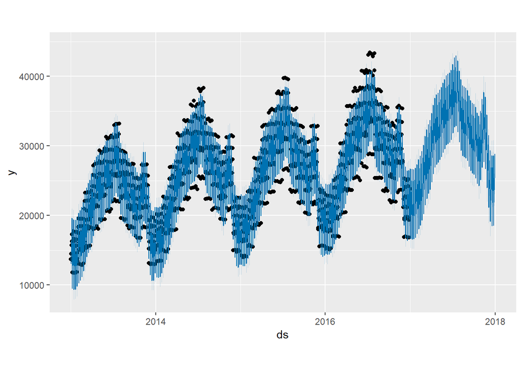

```r
model_holiday <- prophet(changepoint.prior.scale = 0.05,
                         holidays = holiday) %>%
  add_seasonality(name="monthly", period = 30.5, fourier.order = 5) %>%
  fit.prophet(train_sales)
future_holiday <- make_future_dataframe(model_holiday, periods = 365)
forecast_holiday <- predict(model_holiday, future_holiday)
plot(model_holiday, forecast_holiday)
```

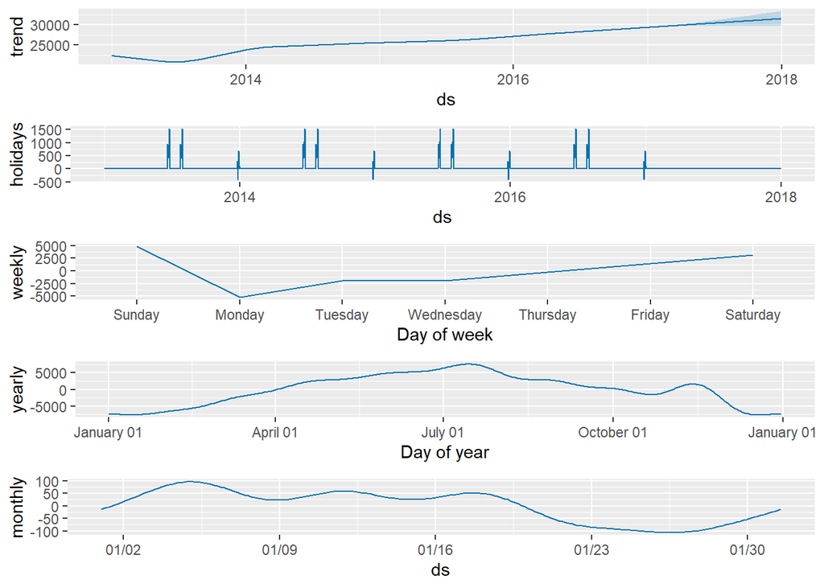

```r
prophet_plot_components(model_holiday, forecast_holiday)
```

Try various turning, then we can see trend, holiday, weekly, monthly, and yearly.

# Model Evaluation

Import test file for test our model. This is to ensure our model and evaluate to be better performance.

```r
test_data <- read.csv("data_input/dive-deeper/test.csv")
glimpse(test_data)
```

```
## Rows: 182,500
## Columns: 4
## $ date  <chr> "2017-01-01", "2017-01-02", "2017-01-03", "2017-01-04", "2017...
## $ store <int> 1, 1, 1, 1, 1, 1, 1, 1, 1, 1, 1, 1, 1, 1, 1, 1, 1, 1, 1, 1, 1...
## $ item  <int> 1, 1, 1, 1, 1, 1, 1, 1, 1, 1, 1, 1, 1, 1, 1, 1, 1, 1, 1, 1, 1...
## $ sales <int> 19, 15, 10, 16, 14, 24, 14, 20, 18, 11, 14, 17, 7, 16, 29, 15...
```

This data also must has same format to fit with prophet, so let this manipulate its column name.

```r
test_2 <- test_data %>%
  mutate(date = ymd(date)) %>%
  arrange(date)
```

```r
test_3 <- test_2 %>%
  group_by(date) %>%
  summarise(
    demand = sum(sales)
  )
```

```r
test <- test_3 %>%
  rename(
    ds = "date",
    y = "demand"
  )
head(test)
```

```
## # A tibble: 6 x 2
##   ds             y
##   <date>     <int>
## 1 2017-01-01 23709
## 2 2017-01-02 15772
## 3 2017-01-03 18650
## 4 2017-01-04 18510
## 5 2017-01-05 19895
## 6 2017-01-06 20994
```

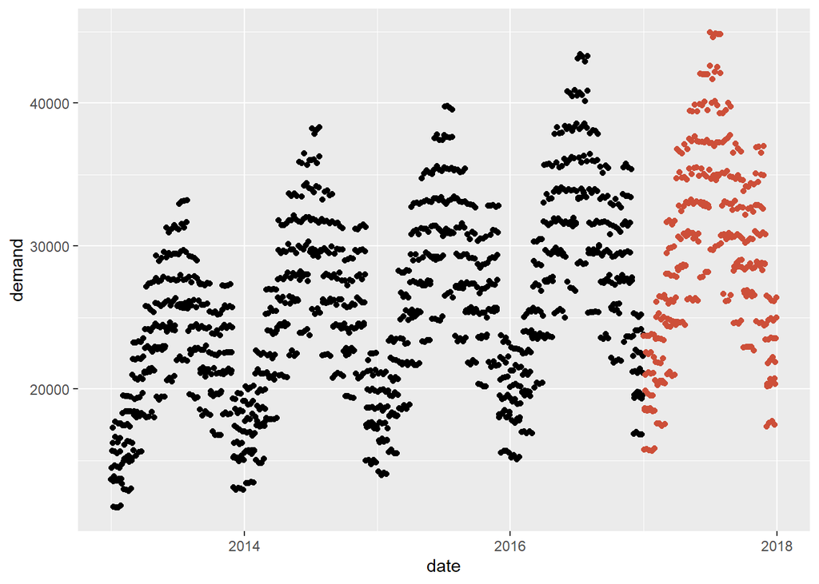

```r
cutoff <- dmy("01-01-2016")
train <- daily_demand %>%
  rename(
    "ds" = date,
    "y" = demand
  )

ggplot(daily_demand, aes(x=date, y=demand)) +
  geom_point(data=train, aes(x=ds, y=y)) +
  geom_point(data=test, aes(x=ds, y=y), color="tomato3")
```

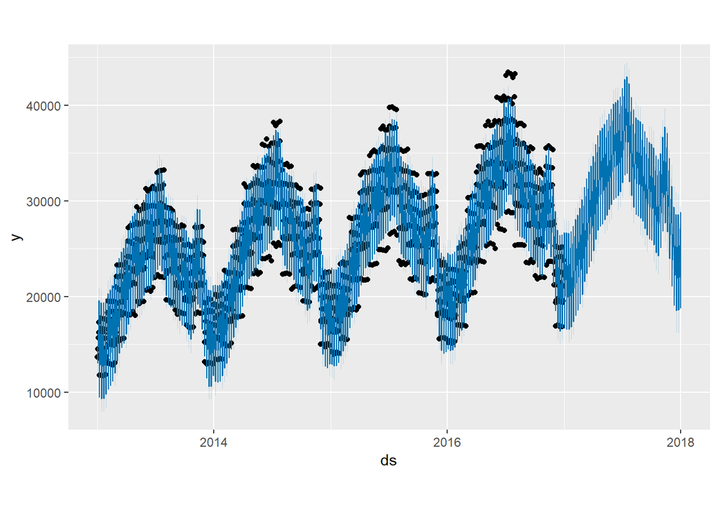

```r
model_final <-prophet(changepoint.prior.scale = 0.05,
                      yearly.seasonality = TRUE,
                      holidays = holiday) %>%
  add_seasonality(name = "monthly", period = 30.5, fourier.order = 5) %>%
  fit.prophet(train)
future_final <-make_future_dataframe(model_final, periods = nrow(test)+1)
forecast_final <- predict(model_final,future_final)
plot(model_final, forecast_final)
```

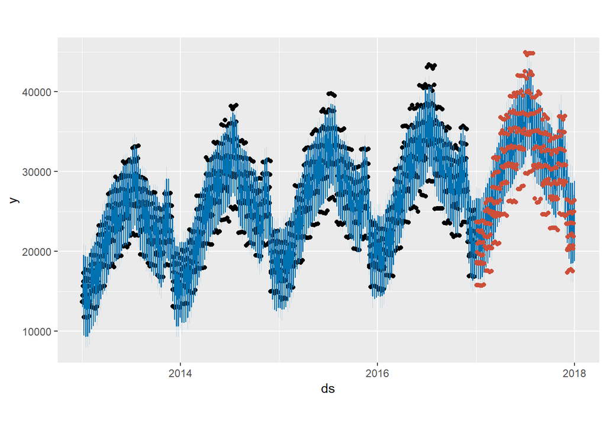

```r
plot(model_final, forecast_final) +
  geom_point(data = test %>% mutate(ds=as.POSIXct(ds)), aes(x=ds, y=y), color="tomato3")
```

```r
eval <- test %>%
  mutate(
    ds = as.POSIXct(ds)
  ) %>%
  left_join(forecast_final) %>%
  select(ds, y, yhat, yhat_upper, yhat_lower)
eval
```

```
## # A tibble: 365 x 5
##    ds                      y   yhat yhat_upper yhat_lower
##    <dttm>              <int>  <dbl>      <dbl>      <dbl>
##  1 2017-01-01 00:00:00 23709 26708.     28180.     25363.
##  2 2017-01-02 00:00:00 15772 16672.     18042.     15309.
##  3 2017-01-03 00:00:00 18650 20034.     21573.     18594.
##  4 2017-01-04 00:00:00 18510 20084.     21382.     18713.
##  5 2017-01-05 00:00:00 19895 21692.     23085.     20354.
##  6 2017-01-06 00:00:00 20994 23372.     24771.     22061.
##  7 2017-01-07 00:00:00 22591 24989.     26369.     23601.
##  8 2017-01-08 00:00:00 23700 26659.     27972.     25382.
##  9 2017-01-09 00:00:00 15797 16567.     17892.     15168.
## 10 2017-01-10 00:00:00 18608 19897.     21213.     18545.
## # ... with 355 more rows
```

We score our model with MAPE, to know how many percent this model has risk, before we give it to stakeholder or business.

```r
mape <- function(y, yhat) {
  return(mean(abs(y - yhat)/ y))
}
mape(eval$y, eval$yhat)
```

```
## [1] 0.05537844
```

So, this model has around 6% MAPE. Real condition can be upper or lower than our prediction.

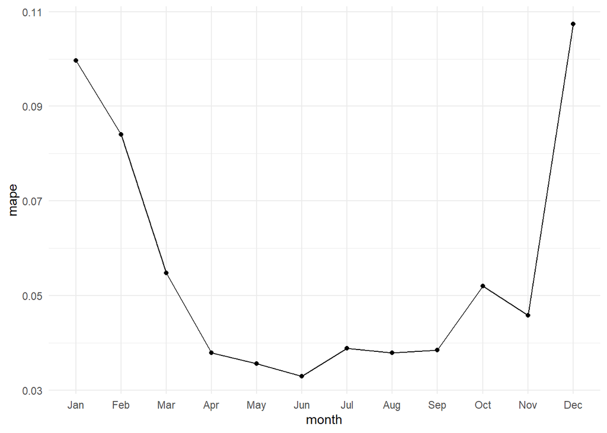

```r
eval %>%
  mutate(
    month=month(ds, label = T)
  ) %>%
  group_by(month) %>%
  summarise(
    mape = mean(abs(y-yhat)/y)
  ) %>%
  ggplot(aes(x=month, y=mape)) +
  geom_line(group=1) +
  geom_point() +
  theme_minimal()
```

This graph shows how MAPE per month. Best result on May until September, but has high risk on December and January. This evaluation can improve this model better with optimization in higher percent.

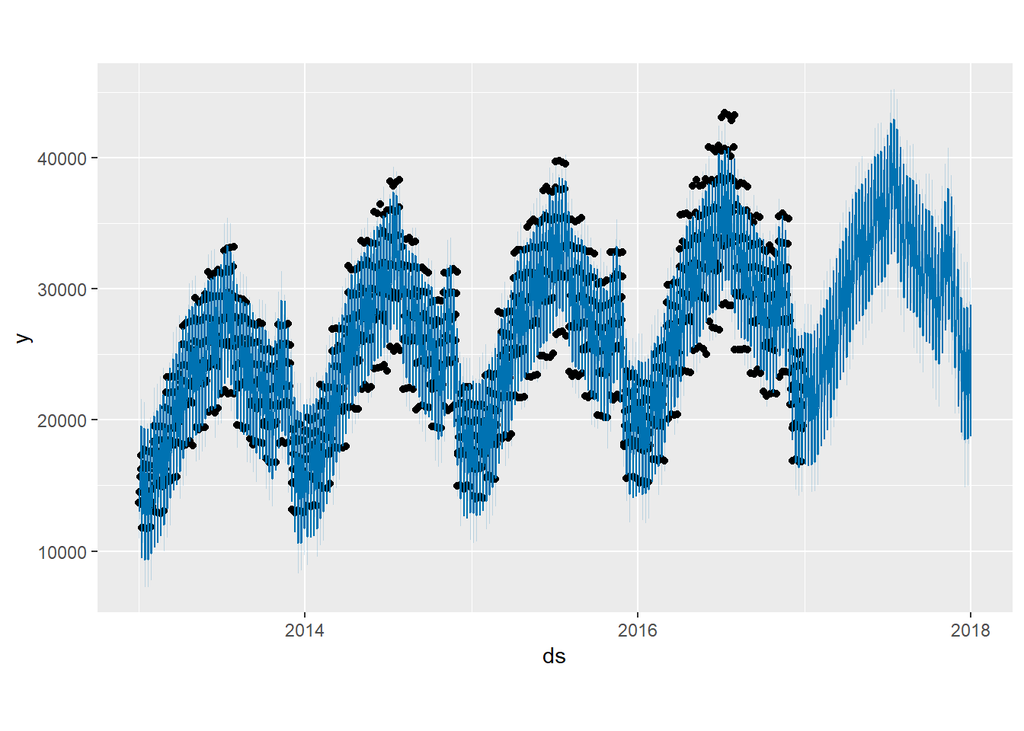

```r
model_interval <- prophet(changepoint.prior.scale = 0.05,
                          yearly.seasonality = TRUE,
                          holidays = holiday,
                          interval.width = 0.95) %>%
  add_seasonality(name = "monthly", period = 30.5, fourier.order = 5) %>%
  fit.prophet(train)
future_interval <- make_future_dataframe(model_interval, periods = nrow(test)+1)
forecast_interval <- predict(model_interval, future_interval)
plot(model_interval, forecast_interval)
```

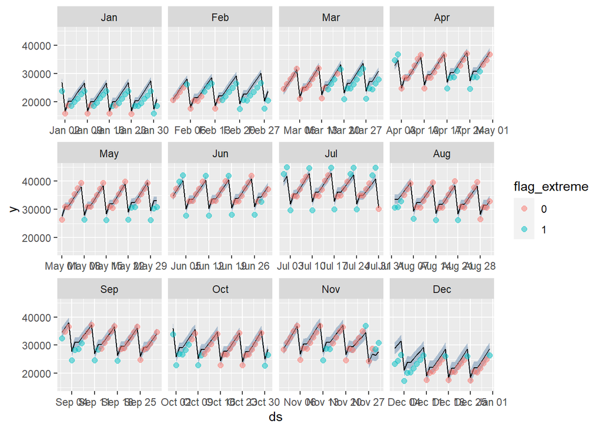

```r
eval %>%
  mutate(
    flag_extreme = ifelse(y > yhat_upper | y < yhat_lower, "1", "0"),
    month = month(ds, label = T),
  ) %>%
ggplot(aes(x=ds, y=y)) +
  geom_ribbon(aes(ymin=yhat_lower, ymax=yhat_upper), alpha = 0.3, fill="dodgerblue4") +
  geom_line(aes(x=ds, y=yhat)) +
  geom_point(aes(color=flag_extreme), alpha = 0.5, size = 2) +
  facet_wrap(~month, scales = "free_x")
```